# Project: Investigate (No-Show appointment Dataset)

### Research Question 2 (Which is more likely to show up in the appointment,The one who has scholarship or the one who hasn't ?)

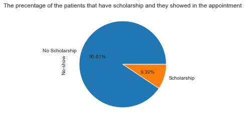

```python
#Calculate the precentage of the patients that have scholarship from the total showed up patients
labels= ['No Scholarship', 'Scholarship']
df_show.groupby(['Scholarship'])['No-show'].count().plot(kind='pie', autopct='%1.2f%%',labels=labels);
plt.title('The precentage of the patients that have scholarship and they showed in the appointment');
```

```python
#Calculate the precentage of showed up patients that have scholaship and that doesn't have.
df.groupby(['Scholarship'])['No-show'].value_counts(normalize=True)
```

```
Scholarship  No-show
0            No         0.801967
             Yes        0.198033
1            No         0.762637
             Yes        0.237363
Name: No-show, dtype: float64
```

- The plot shows that more than 90% of the patients that showed up in thier appointment did not have a scholarship
- Also 76% from the people that have scholarship had showed up and 80% of the people that have not scholarship has showed up so it seems like having scholarship does not affect if the patient will show up or not.

### Research Question 3 (What is the precentage of each gender that showed up,and does the gender affect if the paitent showed up or not ?)

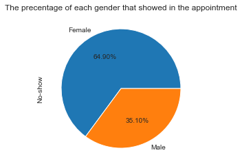

```python
#Calculate the precentage of gender from the total number of showed up patients
labels= ['Female', 'Male']
df_show.groupby(['Gender'])['No-show'].count().plot(kind='pie', autopct='%1.2f%%',labels=labels);
plt.title('The precentage of each gender that showed in the appointment');
```

```python
#Calculate the precentage of the showed up patients from each gender
df.groupby(['Gender'])['No-show'].value_counts(normalize=True)
```

```
Gender  No-show
F       No         0.796885
        Yes        0.203115
M       No         0.800362
        Yes        0.199638
Name: No-show, dtype: float64
```

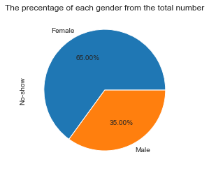

```python
#Calculate the precentage of each gender from the total number of patients
df.groupby(['Gender'])['No-show'].count().plot(kind='pie', autopct='%1.2f%%',labels=labels);
plt.title('The precentage of each gender from the total number');
```

> 65% of the total paitents are females and 35% are males and it is almost the same precentage of the showed up gender. it means that the most showed up are female because they are more than males in the total numbers, so paitent's gender does not affect if he/she will show up or not.

### Research Question 4 (What is the ratio of patients suffering from different kinds of diseases, respectively?)

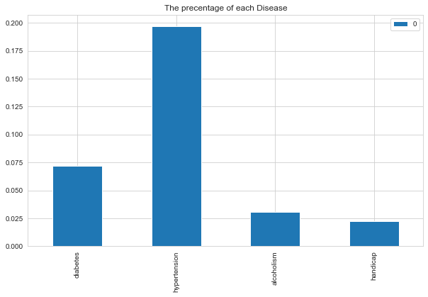

```python
#Calculate the ratio of each diseases sum/total count
diab = df['Diabetes'].sum()/df['Diabetes'].count()
hype = df['Hipertension'].sum()/df['Hipertension'].count()
alco = df['Alcoholism'].sum()/df['Alcoholism'].count()
hand = df['Handcap'].sum()/df['Handcap'].count()
d={'diabetes':diab,
   'hypertension':hype,
   'alcoholism':alco,
   'handicap':hand
   }
#convert dictionary to dataframe and plot it
df_bar = pd.DataFrame.from_dict(d, orient='index')
df_bar.plot(kind='bar',figsize=(10,6));
plt.title('The precentage of each Disease');
#sns.barplot(['diabetes', 'hypertension', 'alcoholism', 'handicap'],[diab, hype, alco, hand], alpha = 0.8);
```

### Research Question 5 (What is the precentage of the patients that recieved SMS ? And how does it affect ?)

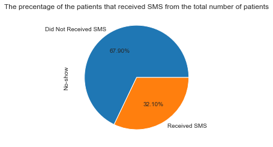

```python
#The precentage of the patient that recieverd SMS from the total number
labels= ['Did Not Received SMS', 'Received SMS']
df.groupby(['SMS_received'])['No-show'].count().plot(kind='pie',autopct='%1.2f%%',labels=labels);
plt.title('The precentage of the patients that received SMS from the total number of patients');
```

```python
df.groupby(['SMS_received'])['No-show'].value_counts(normalize=True)
```

```
SMS_received  No-show
0             No         0.833020
              Yes        0.166980
1             No         0.724255
              Yes        0.275745
Name: No-show, dtype: float64
```

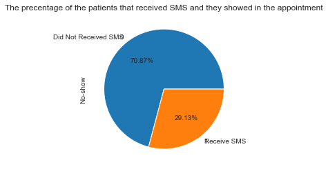

```python
#Calculate the precentage of the patients that recieved SMS and that didn't
df_show.groupby(['SMS_received'])['No-show'].count().plot(kind='pie');
labels= ['Did Not Received SMS', 'Receive SMS']
df_show.groupby(['SMS_received'])['No-show'].count().plot(kind='pie',autopct='%1.2f%%',labels=labels);
plt.title('The precentage of the patients that received SMS and they showed in the appointment');
```

From These results and plots we find that

- Only 32% from the patients had recieved SMS and Only 72% from them did showed up.
- 70% from the patients that showed up did not recieve SMS

```python
#Calculate The SMS effect on showing up to each age category
df.groupby(['Age_Category','SMS_received'])['No-show'].value_counts(normalize=True)
```

```
Age_Category  SMS_received  No-show
Child         0             No         0.815684
                            Yes        0.184316
              1             No         0.694283
                            Yes        0.305717
Teen          0             No         0.807559
                            Yes        0.192441
              1             No         0.632521
                            Yes        0.367479
Youth         0             No         0.838911
                            Yes        0.161089
              1             No         0.737518
                            Yes        0.262482
Old           0             No         0.865336
                            Yes        0.134664
              1             No         0.800764
                            Yes        0.199236
Very Old      0             No         0.800000
                            Yes        0.200000
              1             No         0.794521
                            Yes        0.205479
Name: No-show, dtype: float64
```

From This table we find that the precentage of the showed up patients that recieved SMS for each category are

- 69% from the childs that recieve SMS has showed up
- 63% from The teenagers
- 73% from Youth
- 80% from old people
- 79% from people above 90

### Research Question 6 (What are the most Neighbourhoods has the highest numbers of showed up patients ?)

```python
x=df_show.groupby(['Neighbourhood'])['No-show'].count()
#Convert the pd series to dataframe
y=x.to_frame()
x.idxmax()
```

```
'JARDIM CAMBURI'
```

```python
y.describe()
```

|  | No-show |
| --- | --- |
| count | 80.00000 |
| mean | 1102.58750 |
| std | 1096.25939 |
| min | 1.00000 |
| 25% | 324.00000 |
| 50% | 709.50000 |
| 75% | 1605.00000 |
| max | 6252.00000 |

```python
#From the describesion we find that the highest Neighbourhood according to show is more than 75% (1605)
df_high=y[y['No-show']>1605]
#The highest Neighbourhood according to show in appointment
df_high.head(20)
```

| Neighbourhood | No-show |
| --- | --- |
| ANDORINHAS | 1741 |
| BONFIM | 2223 |
| CARATOÍRA | 1974 |
| CENTRO | 2631 |
| DA PENHA | 1788 |
| ILHA DO PRÍNCIPE | 1734 |
| ITARARÉ | 2591 |
| JABOUR | 2058 |
| JARDIM CAMBURI | 6252 |
| JARDIM DA PENHA | 3246 |
| JESUS DE NAZARETH | 2157 |
| MARIA ORTIZ | 4586 |
| NOVA PALESTINA | 1862 |
| RESISTÊNCIA | 3525 |
| ROMÃO | 1740 |
| SANTA MARTHA | 2635 |
| SANTO ANDRÉ | 2063 |
| SANTO ANTÔNIO | 2262 |
| SÃO PEDRO | 1933 |
| TABUAZEIRO | 2559 |

- This Table shows the highest 20 Neighbourhood according to the showed up patients
- And The highest one is 'JARDIM CAMBURI'